# FigureYa159LR_RF

小丫画图出品

2020-2-2

欢迎关注“小丫画图”公众号，回复“小白”，看小视频，实现点鼠标跑代码。

小丫微信: epigenomics E-mail: figureya@126.com

作者：大鱼海棠

单位：Research Center of Biostatistics and Computational Pharmacy, China Pharmaceutical University

小丫编辑校验

# 需求描述

虽然FigureYa65SVM里有lasso和SVM，还想试试RF和LR，而且用五折交叉验证画AUC也有点问题。

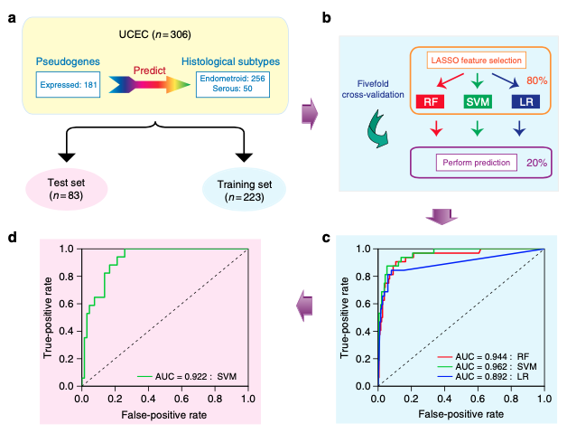

出自https://www.nature.com/articles/ncomms4963

Figure 3 | The predictive power of pseudogene expression in classification of UCEC subtypes. (a) The UCEC dataset (n 1⁄4 306) was split into training (n 1⁄4 223) and test (n 1⁄4 83) sets. (b) Schematic representation of feature selection and classifiers building through fivefold cross-validation within the training set. (c) The receiver operating characertistic curves of the three classifiers based on the cross-validation within the training set. (d) The receiver operating characertistic curve from applying the best-performing classifier (SVM) built from the whole training set to the test set.

# 应用场景

# 环境设置

使用国内镜像安装包

```r
options("repos"= c(CRAN="https://mirrors.tuna.tsinghua.edu.cn/CRAN/"))
options(BioC_mirror="http://mirrors.ustc.edu.cn/bioc/")
```

加载包

```r
library(glmnet) # 做LASSO和LR
library(randomForest) # 做RF
library(pROC) # 绘制ROC
Sys.setenv(LANGUAGE = "en") #显示英文报错信息
options(stringsAsFactors = FALSE) #禁止chr转成factor
```

# 输入文件

easy_input.csv，带有分组信息的矩阵，这里用跟FigureYa65SVM同一个输入文件，数据预处理过程可参考FigureYa65SVM。

可自行准备，至少包含以下信息：

- 第一列：sample ID
- 第二列：样本分组信息，最好为二分类变量
- 第三列之后：表达矩阵

```r
# 加载输入数据
dat <- read.csv("easy_input.csv",row.names = 1,header = T,check.names = F,stringsAsFactors = F)
sam <- rownames(dat) # 取出样本名
```

# 按例文的方法一步步实现

包含四步：

- 第一步：构建5-fold交叉验证的样本集
- 第二步：LASSO回归在训练集里筛选变量
- 第三步：利用LR在4折数据中构建预测模型，验证余下1折
- 第四步：利用RF在4折数据中构建预测模型，验证余下1折

```r
# 1. 例文第一步：构建5-fold交叉验证的样本集

# 自定义函数分割样本（无重复）
createFolds <- function(strat_id, k, seed = 123456) {
  set.seed(seed)
  if(k > length(strat_id)) {
    k <- length(strat_id)
  }
  perm <- sample(length(strat_id))
  strat_id <- factor(strat_id, levels=sample(unique(strat_id)))

  strat_order <- order(strat_id[perm])

  num_item_per_fold_ceil <- ceiling(length(strat_id) / k)

  fold_ids <- rep(seq_len(k), times= num_item_per_fold_ceil)
  fold_ids <- fold_ids[seq_along(strat_id)]

  folds <- split(perm[strat_order], fold_ids)
  names(folds) <- paste0("Fold", seq_len(k))
  return(folds)
}

# 样本随机分为5-fold且不重复
n.fold <- 5 # 交叉验证次数
seed = 12345678 # 设置种子使得结果可重复
fold <- createFolds(sam,n.fold,seed = seed)

test_pred_LR <- test_pred_RF <- NULL # 初始化结果数据框
for (i in 1:n.fold) {
  train_sam <- sam[-fold[[i]]] # 去除该折，即余下4折为训练集
  test_sam <- setdiff(sam,train_sam) # 余下样本为测试集

  # 训练集数据
  train_dat <- dat[train_sam,]
  train_dat$group <- ifelse(train_dat$group == "NR",0,1)

  # 验证集数据
  test_dat <- dat[test_sam,]
  test_dat$group <- ifelse(test_dat$group == "NR",0,1)

  # 2. 例文第二步：LASSO回归在训练集里筛选变量
  set.seed(seed)
  x <- as.matrix(train_dat[,setdiff(colnames(train_dat),"group")])
  y <- train_dat$group
  cvfit = cv.glmnet(x, y,
                    nfold=10, #10-fold cross-validation
                    family = "binomial", type.measure = "class")
  myCoefs <- coef(cvfit, s="lambda.min")
  lasso_fea <- rownames(coef(cvfit, s = 'lambda.min'))[coef(cvfit, s = 'lambda.min')[,1]!= 0] # 提出系数非0的变量
  lasso_fea <- setdiff(lasso_fea,"(Intercept)")

  # 3. 例文第三步：利用LR在4折数据中构建预测模型，验证余下1折
  # 用lasso features构建LR预测模型

  cat("LR",i,"...\n")
  model_LR <- glm(group ~ .,
                  data = train_dat,
                  family = "binomial")

  # 基于LR算法预测验证集概率，并合并真实结果
  test_pred_LR <- rbind.data.frame(test_pred_LR,
                                   data.frame(prob = predict(model_LR, newdata = test_dat,type="response"),
                                              group = test_dat$group,
                                              stringsAsFactors = F),
                                   stringsAsFactors = F)

  # 4. 例文第四步：利用RF在4折数据中构建预测模型，验证余下1折
  # 用lasso features构建RF预测模型
  cat("RF",i,"...\n")
  model_RF <- randomForest(group ~ .,
                           data = train_dat,
                           ntree = 1000, # 树的数目，例文为1000
                           nPerm = 50, # 扰动次数，一般为50
                           mtry = floor(sqrt(ncol(train_dat)-1)),
                           proximity = T,
                           importance = T)

  # 基于RF算法预测验证集概率，并合并真实结果
  test_pred_RF <- rbind.data.frame(test_pred_RF,
                                   data.frame(prob = predict(model_RF, newdata = test_dat,type="response"),
                                              group = test_dat$group,
                                              stringsAsFactors = F),
                                   stringsAsFactors = F)
  cat("\n")
}
```

```
## LR 1 ...
```

```
## RF 1 ...
```

```
##
## LR 2 ...
```

```
## RF 2 ...
```

```
##
## LR 3 ...
```

```
## RF 3 ...
```

```
##
## LR 4 ...
```

```
## RF 4 ...
```

```
##
## LR 5 ...
```

```
## RF 5 ...
```

# 开始画图

绘制ROC，对比LR和RF。

```r
jco <- c("#2874C5","#EABF00")

pdf("LR_RF.pdf")
LR.roc <- plot.roc(test_pred_LR$group,test_pred_LR$prob,ylim=c(0,1),xlim=c(1,0),
                   smooth=F, #绘制平滑曲线
                   ci=TRUE,
                   main="",
                   col=jco[1],#线的颜色
                   lwd=2, #线的粗细
                   legacy.axes=T,
                   print.auc = F)
RF.roc <- plot.roc(test_pred_RF$group,test_pred_RF$prob,ylim=c(0,1),xlim=c(1,0),
                   smooth=F, #绘制平滑曲线
                   ci=TRUE,
                   main="",
                   col=jco[2],#线的颜色
                   lwd=2, #线的粗细
                   legacy.axes=T,
                   print.auc = F,
                   add = T)
legend.label <- c("AUC",paste0("LR: ",round(LR.roc$auc,3)),paste0("RF: ",round(RF.roc$auc,3)))
legend("bottomright",
       legend = legend.label,
       col = c(NA,jco[1:2]),
       lwd = 2,
       bty="n")
invisible(dev.off())
```

[figure not shown]